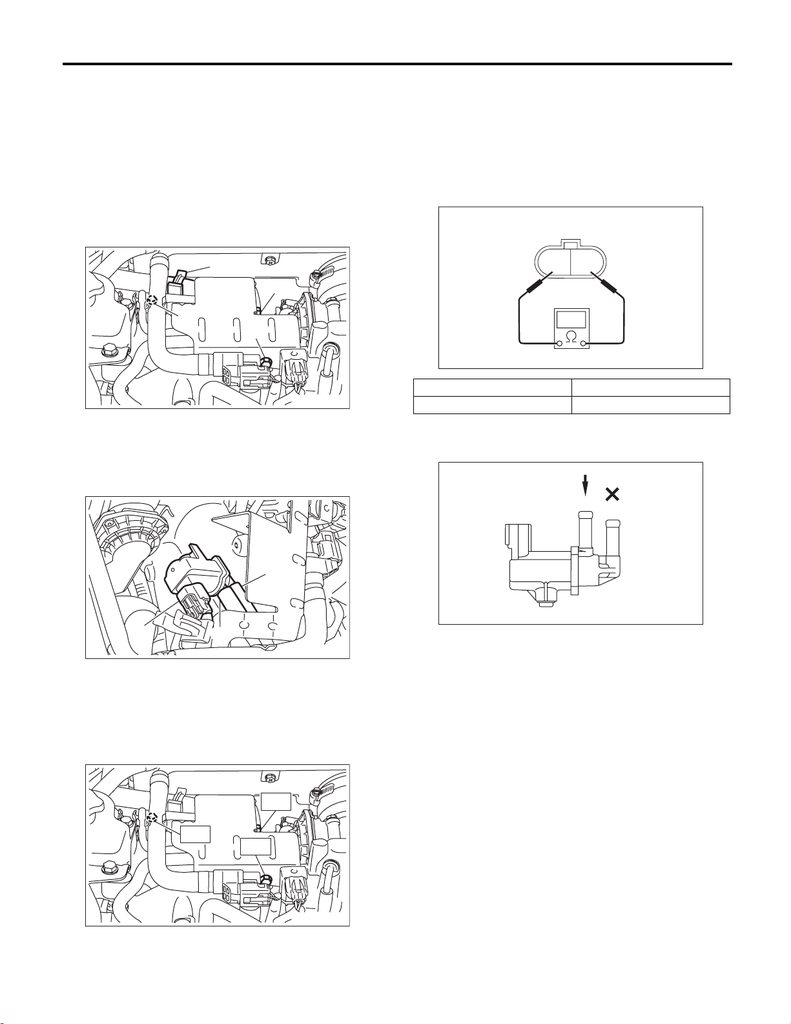

Wastegate Control Solenoid Valve

FUEL INJECTION (FUEL SYSTEMS)

15.Wastegate Control Solenoid

Valve

A: REMOVAL

1) Disconnect the ground cable from battery.

2) Remove the vacuum hose from clip (A), and re-

move the bolt (B) which secures the wastegate

control solenoid valve.

3) Remove the bolts (C) which secure solenoid

valve bracket onto intake manifold.

4) Disconnect the connector (A) from the waste-

gate control solenoid valve.

5) Disconnect the vacuum hose (B) and air control

hose (C) from the wastegate control solenoid valve,

and remove the wastegate control solenoid valve.

B: INSTALLATION

Install in the reverse order of removal.

Tightening torque:

T1: 6.4 N·m (0.7 kgf-m, 4.7 ft-lb)

T2: 19 N·m (1.9 kgf-m, 14.0 ft-lb)

C: INSPECTION

1. WASTEGATE CONTROL SOLENOID

VALVE

1) Check that the wastegate control solenoid valve

has no deformation, cracks or other damages.

2) Check the resistance between the wastegate

control solenoid valve terminals.

3) Check that air does not come out from (B) when

air is blown into (A).

(A)

(C)

(B)

(C)

(A)

(B)

(C)

T1

T1

T2

Terminal No. Standard

1 and 2 28±2 Ω (when 20°C (68°F))

21

EC-02426

FU-04069

(A)

(B)

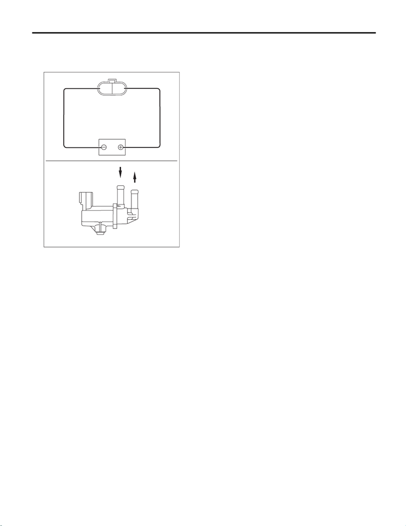

Wastegate Control Solenoid Valve

FUEL INJECTION (FUEL SYSTEMS)

4) Connect the battery positive terminal to the ter-

minal No. 1 and the battery ground terminal to the

terminal No. 2. Check that air is discharged from

(B), when supplying air to (A).

2. OTHER INSPECTIONS

Check that the vacuum hose and air control hose

have no cracks, damage or loose part.

21

(A)

(B)